# Amniote Mass Investment

Erin Keleske

3/22/2018

Species experience tradeoffs for where there energy is spent. In this brief analysis, we will consider one such relationship: energy spent on personal growth and energy spent on the growth of offspring.

## Initial data download —–

Raw data can be found [here](http://www.esapubs.org/archive/ecol/E096/269/#data). and originated from:

> Nathan P. Myhrvold, Elita Baldridge, Benjamin Chan, Dhileep Sivam, Daniel L. Freeman, and S. K. Morgan Ernest. 2015. An amniote life-history database to perform comparative analyses with birds, mammals, and reptiles. Ecology 96:3109.http://dx.doi.org/10.1890/15-0846.1

This data includes common life history data on species from the class Aves, Mammalia, and Reptilia.

## Data exploration and visualisation —–

Assuming females of a given species have reached “adult body mass” by the time of sexual maturity, the relationship betwen these two variables can be used to calculate the approximate growth rate from birth to adulthood.

First, let’s explore the relationship between these variables. Since there’s such a wide range of sizes within the full amniote data, from the Dwarf Gecko to the Blue Whale, the data have been subset into classes and plotted separately.

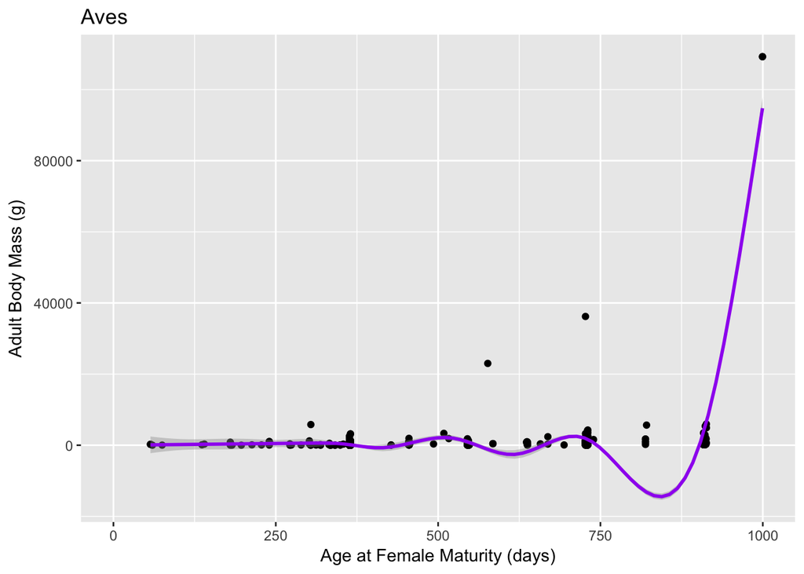

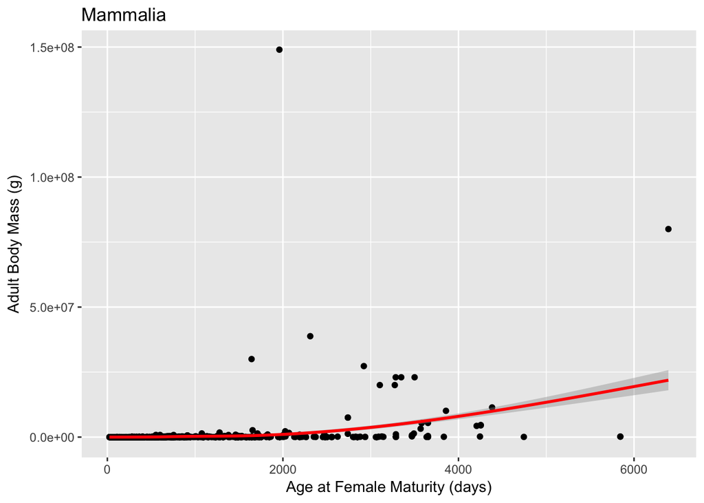

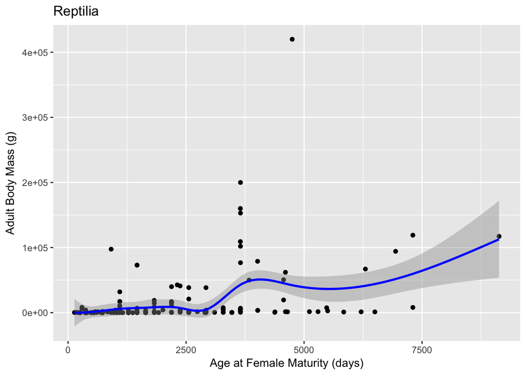

To represent investment in reproduction, we can look at a similar relationship between the weight at birth or hatching divided by gestation period.

Again, data was subset into classes. However, there is no available data on Aves gestation period.

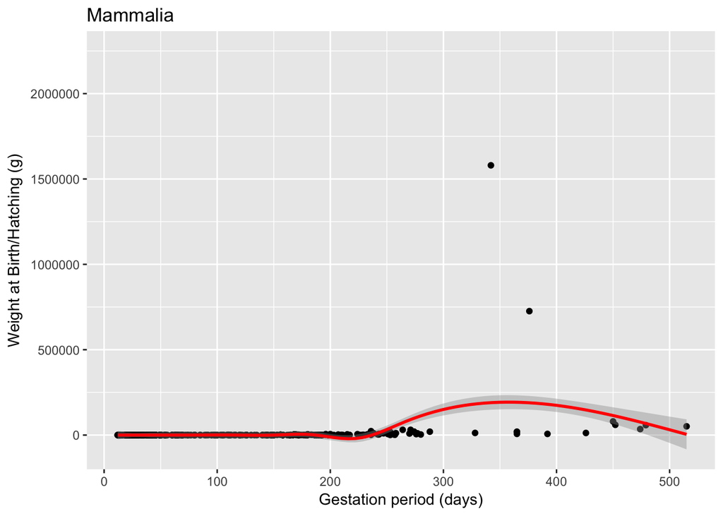

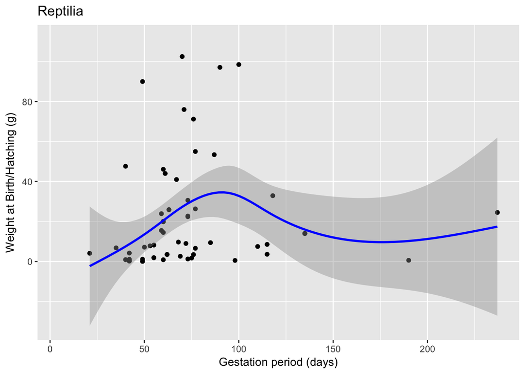

## Relationship between variables —–

Using the two variables from above, I calculated two rates.

Adult growth rate (g/day) = > Adult body mass (g) / Age at female maturity (days)

However, since the offspring of larger animals will always grow more g/day than smaller animals, offspring growth must be considered relative to the full adult size.

Offspring growth rate (g/g/day) = > Birth or hatch weight (g) x Litter or clutch size x Litters or clutches per year/ Adult body mass (g) / Gestation period (days)

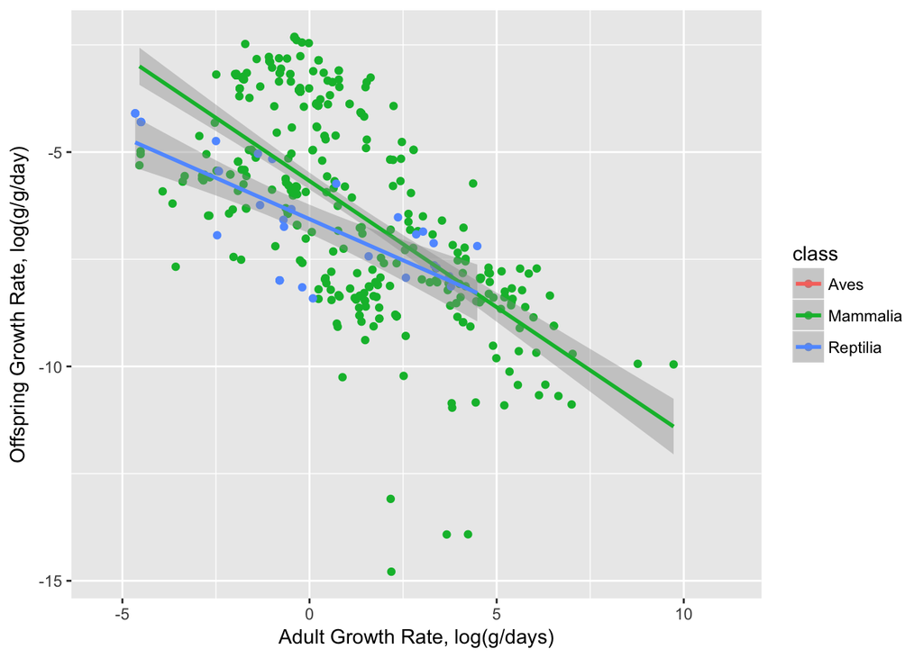

To look at this pattern even further, we can investigate different orders within Mammalia and Reptilia individually.

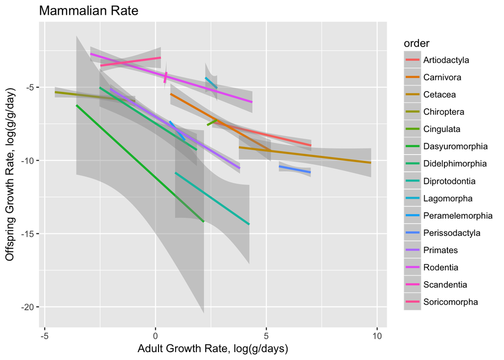

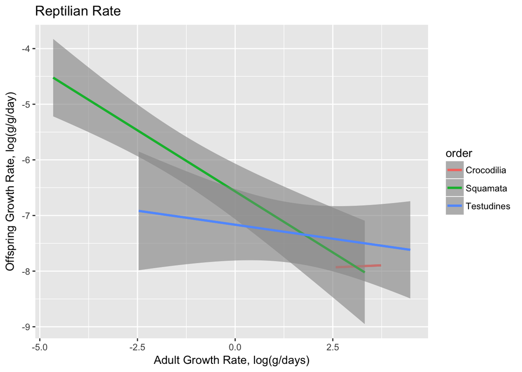

## Distribution of a variable among groups —–

We can create one comparative variable by dividing the two rates.

adult:offspring investment (g) = > Adult growth rate (g/d) /Offspring relative growth rate (g/g/d)

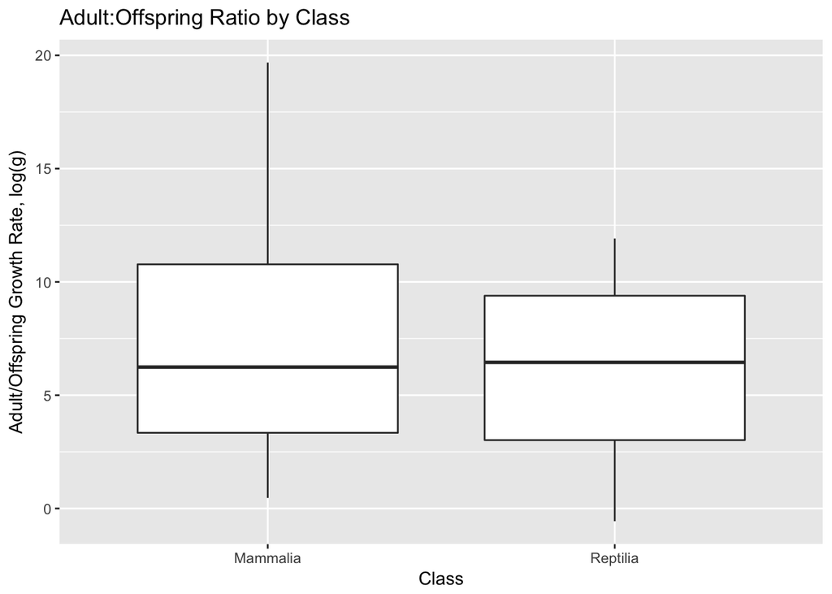